# Tracing the COVID-19 Trajectory Using **Shiny**

Proposal

The project analyzes COVID-19 trends and vaccination impacts globally and in the USA, using visualizations to reveal key patterns and insights.

Authors

Affiliation

**GraphGeeks** - Devendran, Omid, G Sai Laasya

Rajitha, Gowtham, Mrunali

School of Information, University of Arizona

```r
library(tidyverse)
```

## Introduction

Our project leverages a comprehensive COVID-19 dataset from Kaggle to unlock insights into the pandemic’s dynamics through advanced data visualization, utilizing the `Shiny app package` for interactive user experiences. By analyzing case counts, recovery rates, mortality, and vaccination data, we aim to reveal trends and correlations across different regions and periods. This endeavor transcends academic boundaries, aiming to provide actionable insights for policymakers and the public. Through our analysis, which includes dynamic and interactive visualizations made possible by Shiny, we aspire to transform complex data into clear, insightful narratives, aiding in the informed response to this global health crisis.

## Dataset

```r
# Dataset Head
day_wise_data <- read_csv("./data/day_wise.csv")
print(head(day_wise_data))
```

```
# A tibble: 6 × 12
  Date       Confirmed Deaths Recovered Active `New cases` `New deaths`
  <date>         <dbl>  <dbl>     <dbl>  <dbl>       <dbl>        <dbl>
1 2020-01-22       555     17        28    510           0            0
2 2020-01-23       654     18        30    606          99            1
3 2020-01-24       941     26        36    879         287            8
4 2020-01-25      1434     42        39   1353         493           16
5 2020-01-26      2118     56        52   2010         684           14
6 2020-01-27      2927     82        61   2784         809           26
# ℹ 5 more variables: `New recovered` <dbl>, `Deaths / 100 Cases` <dbl>,
#   `Recovered / 100 Cases` <dbl>, `Deaths / 100 Recovered` <dbl>,
#   `No. of countries` <dbl>
```

```r
country_wise_latest_data <- read_csv("./data/country_wise_latest.csv")
print(head(country_wise_latest_data))
```

```
# A tibble: 6 × 15
  `Country/Region`    Confirmed Deaths Recovered Active `New cases` `New deaths`
  <chr>                   <dbl>  <dbl>     <dbl>  <dbl>       <dbl>        <dbl>
1 Afghanistan             27532    546      7660  19326         658           42
2 Albania                  1788     39      1086    663          66            1
3 Algeria                 11385    811      8078   2496         117           12
4 Andorra                   855     52       792     11           1            0
5 Angola                    166      8        64     94          11            1
6 Antigua and Barbuda        26      3        22      1           0            0
# ℹ 8 more variables: `New recovered` <dbl>, `Deaths / 100 Cases` <dbl>,
#   `Recovered / 100 Cases` <dbl>, `Deaths / 100 Recovered` <dbl>,
#   `Confirmed last week` <dbl>, `1 week change` <dbl>,
#   `1 week % increase` <dbl>, `WHO Region` <chr>
```

```r
vaccination_data <- read_csv("./data/country_vaccinations.csv")
print(head(vaccination_data))
```

[output not shown]

## Description

- The datasets employed for this project are derived from an extensive collection on Kaggle, curated by “imdevskp,” which meticulously compiles data pertaining to the COVID-19 pandemic from multiple global sources. This collection encompasses a variety of datasets, each tailored to different analytical needs: day-wise global statistics offer a temporal view of the pandemic’s progression, country-wise latest data provide a snapshot of the current status in each country, and detailed data grouped by country and date facilitate a comparative analysis over time.
- Additionally, there is a dataset specifically focused on the USA, breaking down statistics to the county level, which allows for a more granular examination within the United States. These datasets collectively encompass critical metrics such as case counts, deaths, recoveries, and vaccination figures, equipping researchers with a robust toolkit for a comprehensive and nuanced analysis of the pandemic’s multifarious impacts and trends.
- To enhance the interactive exploration and visualization of this data, we are utilizing the **shiny package** in R, a powerful tool for creating interactive web applications. The Shiny app will allow users to **dynamically filter**, explore, and visualize the data, offering an immersive and user-driven analysis experience that highlights the depth and complexity of the COVID-19 pandemic data.
- The choice of these datasets was motivated by their depth, regular updates, and the potential insights they offer into the global and localized impacts of COVID-19.

[**COVID-19 Dataset Source Link**](https://www.kaggle.com/datasets/imdevskp/corona-virus-report?resource=download&select=country_wise_latest.csv) And [**vaccination Dataset Source Link**](https://www.kaggle.com/datasets/gpreda/covid-world-vaccination-progress?select=country_vaccinations.csv)

| Variable | Description |
| --- | --- |
| Date | Date of the record, crucial for any time-series analysis. |
| Country/Region | Name of the country or region, essential for geographic comparisons. |
| Confirmed | Total confirmed COVID-19 cases, a primary metric for pandemic assessment. |
| Deaths | Total deaths due to COVID-19, important for understanding the fatality rate. |
| Recovered | Total recoveries from COVID-19, indicative of the recovery rate. |
| Active | Total active COVID-19 cases, key for current pandemic status assessment. |
| New cases | New cases on a given date, vital for identifying trends over time. |
| New deaths | New deaths on a given date, important for tracking fatality trends. |
| New recovered | New recoveries on a given date, useful for monitoring recovery trends. |
| Deaths / 100 Cases | Percentage of deaths per 100 confirmed cases, provides context to the death toll. |
| Recovered / 100 Cases | Percentage of recoveries per 100 confirmed cases, gives insight into the recovery trend. |
| Deaths / 100 Recovered | Percentage of deaths per 100 recovered cases, helps understand the severity among recovered cases. |
| total_vaccinations | Total vaccinations administered, crucial for vaccination trend analysis. |
| people_vaccinated | Total individuals vaccinated, key for understanding the vaccination reach. |
| people_fully_vaccinated | Total individuals fully vaccinated, important for assessing herd immunity potential. |
| daily_vaccinations | Number of vaccinations administered per day, essential for daily trend analysis. |
| total_vaccinations_per_hundred | Total vaccinations per 100 people, allows for normalized comparison between regions. |
| people_vaccinated_per_hundred | People vaccinated per 100 people, useful for comparing vaccination rates. |
| people_fully_vaccinated_per_hundred | People fully vaccinated per 100 people, important for understanding comprehensive vaccination progress. |

## Questions

### Question 1

How has the COVID-19 pandemic trended globally over time, and what correlations can be observed between different pandemic metrics (like cases and recoveries)?

### Question 2

What is the relationship between total vaccinations and the reduction in active COVID-19 cases across different Counties in USA?

## Analysis plan

### For the first question:

Dataset: We will utilize the `day_wise_data` dataset, which provides daily global statistics on COVID-19.

**Focus**: Our refined analysis will focus on daily total cases, recoveries, and deaths to observe the pandemic’s evolution over time without losing granularity in the data.

**Visualizations:**

- **Time-Series Plots**: We’ll employ time-series plots to illustrate the daily evolution of total cases, recoveries, and deaths, with separate line graphs for each metric and a combined graph for direct comparison.
- **Daily Percentage Changes**: To capture the pandemic’s dynamics, we’ll calculate and plot daily percentage changes for each metric. Additionally, we’ll compute and visualize correlation coefficients to explore the relationships between these metrics over time.

**Additional Analysis:**

- Rolling Average Analysis: While our primary focus will be on daily data, we’ll also use rolling averages to identify broader trends, ensuring we capture both immediate changes and more extended patterns.
- Anomaly Detection: We plan to identify and analyze any unusual data points or trends, which could indicate significant pandemic events or turning points.

**Interactive Visualization with Shiny:**

- To make our analysis more interactive and user-friendly, we will utilize the shiny package in R to develop a web application. This application will allow users to dynamically interact with the data through filters such as year, country name, and regions. Users can select specific parameters to refine the visualizations, providing a customized view that can highlight trends and patterns of interest within the global scope of the COVID-19 pandemic.
- This dynamic approach will enable users to explore the data in a more granular and personalized manner, enhancing the analytical value of the visualizations.

### For the second question:

**Dataset Utilization**: We will employ the `usa_county_wise_data` dataset, which is rich in localized COVID-19 data for the United States, encompassing each county’s case and vaccination figures. And `vaccination` dataset provides the details of vaccian all over the world.

**Primary Focus**: We aim to analyze and visualize how COVID-19 cases and vaccination rates have evolved over time across U.S. counties and globally, identifying patterns and correlations.

**Visualizations**

- **Choropleth Maps**: We will craft choropleth maps to visually represent the density or intensity of COVID-19 cases and vaccination rates across U.S. counties. This will enable a straightforward interpretation of regional variances and trends.
- **Bubble Maps**: To enhance our spatial analysis, bubble maps will be constructed where each bubble’s size indicates either the number of cases or vaccination rates in counties, offering a dual perspective on the pandemic’s magnitude and the vaccination effort.
- **Time-Lapse Visualizations**: Implementing time-lapse maps will allow us to observe and analyze the progression of the pandemic and vaccination rollout over time, providing dynamic insights into how the situation has evolved across different regions.

### Plan of Action

| Task Name | Status | Assignee | Due | Priority | Summary |
| --- | --- | --- | --- | --- | --- |
| Data Collection | Incomplete | Rajitha Reddy, Omid Zandi, Devendran | 06 Apr 2024 | Moderate | Collection of necessary data |
| Data Exploration | Incomplete | Devendran Vemula, Gowtham GopalaKrishnan | 06 Apr 2024 | Moderate | Cleaning, transformation, integration of data |
| Q1 Time Series Plot | Incomplete | Everyone | 07 Apr 2024 | Moderate | Create mandatory time series plots for the question |
| Q1 Scatter Plot | Incomplete | Devendran Vemula, G Sai Laasya, Rajitha Reddy | 07 Apr 2024 | Moderate | Generate a scatter plot |
| Q2 Identify Trends and Patterns | Incomplete | Mrunali Yadav, Omid Zandi, Gowtham GopalaKrishnan | 07 Apr 2024 | Moderate | Analyze the trends and patterns |
| Q2 Anomaly Detection | Incomplete | G Sai Laasya, Mrunali Yadav | 09 Apr 2024 | Moderate | Detect anomalies in the spread of the pandemic |
| Q2 Choropleth Map & Bubble Maps | Incomplete | Omid, Rajitha | 09 Apr 2024 | Moderate | Create choropleth and bubble maps |
| Q2 Spatial Map | Incomplete | Everyone | 10 Apr 2024 | Moderate | Develop a spatial map |
| Presentation & Write-Up | Incomplete | Everyone | 15 Apr 2024 | Moderate | Prepare the presentation and write-up |

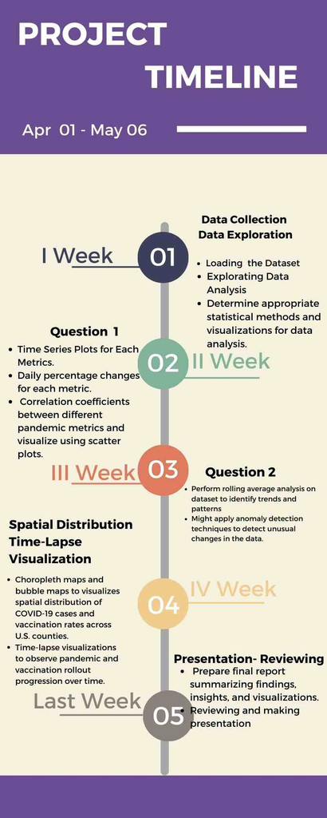